# Statistics for Psychologists 3.

**Computer lab 08**

**Course Number:** BTPS2040BA-E  
**Contact Information:** Please contact me through email anytime: abari.kalman@arts.unideb.hu

Author

Kálmán Abari

Published

April 26, 2025

Learning outcomes

**To earn 1 point**

To earn 1 point, submit all jamovi OMV files in this Computer lab that contain the activities you completed here. The subject of the email should be `Stat3 - Comp. lab 08`. Send the email to `abari.kurzus@gmail.com`.

# Worked Example 1

In this example, we want to group consumers based on their attitudes toward shopping. A total of six attitude variables were considered: respondents were asked to express their agreement with the following statements on a seven-point scale:

- v1: Shopping is fun.
- v2: Shopping is not good for my wallet.
- v3: I often combine shopping with a visit to a restaurant.
- v4: When shopping, I try to get the best deal.
- v5: I am not interested in shopping.
- v6: You can save a lot of money by comparing prices.

The data can be found in the `cluster_customer.xlsx` Excel file.

## Step 1. Import database

Open the `cluster_customer.xlsx` file in jamovi.

[figure not shown]

## Step 2. Measure type

Set the measurement level of the variables. All variables are continuous, so we set the measurement level to `Continuous`.

[figure not shown]

## Step 3. Installing snowCluster plugin

We need to install the `snowCluster` module to perform clustering analysis in jamovi. This module is not included in the default jamovi installation, so we need to install it separately.

To do this, go to the `Modules` icon in the top menu and select `jamovi library`.

[figure not shown]

In the search box, type `snowCluster` and click on the `Install` button. If it has already been installed, you can skip this step. If you would see the `Update` button instead of the `Install` button, click on it to update the module.

[figure not shown]

After the installation is complete, you will see the `snowCluster` icon in the top menu. Click on it to open the module.

[figure not shown]

We will use 3 menu items in the `snowCluster` module:

- `Hierarchical clustering` menu for performing hierarchical clustering.
- `Clustering Dendrogram` menu for a better visualizing the results of hierarchical clustering.
- `K-means clustering` menu for performing K-means clustering.

## Step 4. Hierarchical clustering

We start with hierarchical clustering. To do this, go to the `snowCluster` menu and select `Hierarchical clustering`.

Drag and drop the variables `v1`, `v2`, `v3`, `v4`, `v5`, and `v6` into the `Variables` box. Then, check the Results pane to see the results of the clustering analysis.

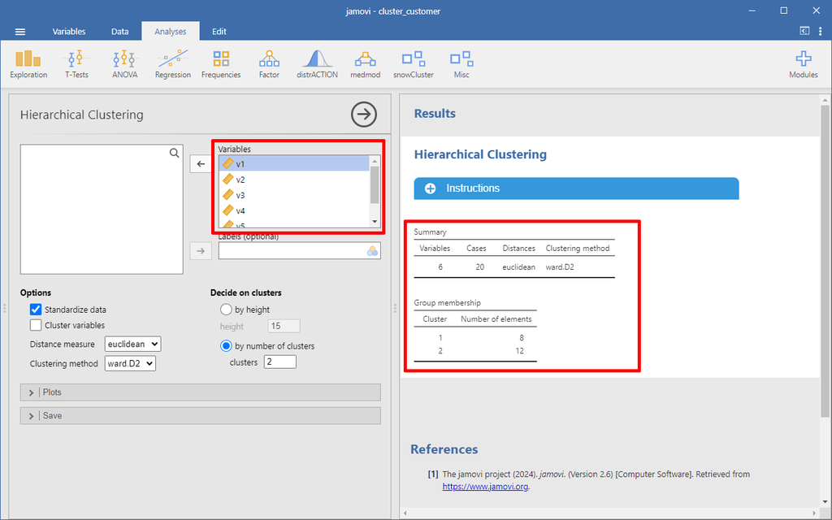

**Interpretation of Hierarchical Clustering in Jamovi:**

- Settings (left panel)
  - Variables: Six variables (v1, v2, v3, v4, v5, v6) were selected for the clustering analysis.
  - Options:
    - Standardize data (checked): The variables were standardized (mean = 0, standard deviation = 1), which is important when variables are measured on different scales. In this case, all variables are on the same scale (1-7), so this option is not necessary.
    - Distance measure: Euclidean distance was used. This is the classic “straight line” distance between two points in space. We will dicuss this in more detail later.
    - Clustering method: ward.D2 method was chosen. The Ward method tries to minimize the variance within each cluster. We will dicuss this in more detail later.
  - Decide on clusters:
    - By number of clusters was selected, and the number was set to 2 clusters.
- Results (right panel)
  - Summary section:
    - Variables: 6 variables were included in the clustering.
    - Cases: There were 20 cases (participants/data points).
    - Distances: Euclidean distance was used.
    - Clustering method: ward.D2 was applied.
  - Group membership:
    - Cluster 1: 8 elements (participants) belong to this group.
    - Cluster 2: 12 elements belong to this group.

The 20 participants were divided into 2 groups based on their scores on the 6 variables: Cluster 1 contains 8 people. Cluster 2 contains 12 people.

## Step 5. Drawing a dendrogram (tree diagram)

We can draw a **dendrogram** (tree diagram). It would help you visually inspect how close or distant the clusters are from each other.

Open the Plot bar, and check the `Dendrogram` box.

[figure not shown]

To understand the dendrogram, we need to know how the hierarchical clustering algorithm works. The dendrogram is a tree-like diagram that shows the arrangement of the clusters. It is a visual representation of the hierarchical clustering process.

To understand the hierarchical clustering algorithm, we need to understand the concept of distance. The distance between two points is a measure of how far apart they are. In hierarchical clustering, we use a distance measure to determine how similar or dissimilar the data points are.

How to interpret the distance between cases (people, participants). It is very important, because it is the basis of clustering analysis. The main idea of clustering analysis is to group similar cases (people, participants) together, and to separate dissimilar cases (people, participants) from each other.

The distance between two cases is a measure of how similar they are. The smaller the distance, the more similar the cases are. - An example of distance is the sum of the absolute differences between their scores on each variable. It is called the **Manhattan distance**. For example 2 cases with the following scores on 3 variables: 6,4,7 and 2,3,1. The distance between these two cases is |6-2| + |4-3| + |7-1| = 4 + 1 + 6 = 11. Two cases with identical points represent zero Euclidean distance. - The distance between two cases is the sum of the squared differences between their scores on each variable. It is called the **Euclidean distance**.

Take a look at the following three cases (participants) from the dataset:

[figure not shown]

The first person has the following scores on the six variables: 6,4,7,3,2,3. That means, based on v1, she/he thinks shopping is fun, because she/he scored 6. Based on v2, she/he thinks shopping is not good and not bad for her/his wallet, because she/he scored 4. She/he can not decide whether shopping is good or bad for her/his wallet. Based on v3, she/he often combines shopping with a visit to a restaurant, because she/he scored 7. Based on v4, she/he tries to get and does not try to get the best deal when shopping, because she/he scored 3. Based on v5, she/he is interested in shopping, because she/he scored 2. This item v5 is reverse coded. Based on v6, she/he thinks and does not think you can save a lot of money by comparing prices, because she/he scored 3. So, based on these six variables, she/he is very positive about shopping.

We can see that the third person received similar scores as the first person. We can predict that the third person has a similar attitude toward shopping as the first person, so they may belong to the same cluster.

But, the second person has the following scores on the six variables: 2,3,1,4,5,4. That means, based on v1, she/he thinks shopping is not fun, because she/he scored 2. Based on v2, she/he thinks and does not think shopping is good for her/his wallet, because she/he scored 3. She/he can not decide whether shopping is good or bad for her/his wallet. Based on v3, she/he does not often combine shopping with a visit to a restaurant, because she/he scored 1. Based on v4, she/he tries to get and does not try to get the best deal when shopping, because she/he scored 4. Based on v5, she/he is not interested in shopping, because she/he scored 5. This item v5 is reverse coded. Based on v6, she/he thinks and does not think you can save a lot of money by comparing prices, because she/he scored 4. So, based on these six variables, she/he is not very positive about shopping.

This person may not belong to the same cluster as the first (and third) person, because their scores are very different.

Now, we can understand the distance between the cases. There is another important concept in hierarchical clustering: the distance between clusters. The distance between two clusters is a measure of how similar or dissimilar the clusters are. The smaller the distance, the more similar the clusters are. There are several ways to calculate the distance between clusters. The most common methods are:

- **Single linkage**: The distance between two clusters is the minimum distance between any two points in the clusters.
- **Complete linkage**: The distance between two clusters is the maximum distance between any two points in the clusters.
- **Average linkage**: The distance between two clusters is the average distance between all points in the clusters.
- **Centroid linkage**: The distance between two clusters is the distance between the centroids of the clusters.
- **Ward’s method**: The distance between two clusters is the increase in the total within-cluster variance when the two clusters are merged. This method tries to minimize the variance within each cluster.

We can set the distance measure and clustering method in the `Hierarchical clustering` menu. In this example, we used the `Euclidean distance` and `Ward's method`. These settings are the default settings in jamovi. The `Euclidean distance` is the most common distance measure used in clustering analysis. The `Ward's method` is the most common clustering method used in hierarchical clustering.

Based on the dendrogram, we can understand how the hierarchical clustering algorithm works. The dendrogram shows the distances between the clusters. The height of the branches indicates the distance between the clusters. The higher the branches, the more distant the clusters are from each other.

How hierarchical clustering works:

1. We start with each data point as a separate cluster.
2. We calculate the distance between each pair of clusters.
3. We merge the two closest clusters into a new cluster. The first two clusters are merged into a new cluster. They may be the cases 10 and 16, because they are the most similar cases. The distance between them is the smallest. So, from the 20 clusters, we have 19 clusters.
4. We repeat steps 2 and 3 until all data points are in a single cluster.  
   The second two clusters are merged into a new cluster. They may be the cases 6 and 7, because they are the most similar cases. The distance between them is the smallest. So, from the 19 clusters, we have 18 clusters. And so on.

How to interpret the dendrogram:

- The y-axis represents the distance between the clusters.
- The x-axis represents the data points (participants).
- The branches represent the clusters.
- The height of the branches indicates the distance between the clusters.
- The closer the branches are, the more similar the clusters are.

## Step 6. Optimal number of clusters based on dendrogram

We can switch to a new Dendrogram view. To do this, go to the `snowCluster` menu and select `Clustering Dendrogram`.

Do the following settings:

[figure not shown]

As we can see, a horizontal dendrogram is displayed.

Two main clusters are shown, each in a different color: - Blue cluster (top). - Orange cluster (bottom).

Each number (e.g., 1, 2, 3, etc.) represents a participant or data case.

The length of the horizontal branches (measured along the “Height” axis) indicates the distance or dissimilarity between clusters or cases:

Shorter horizontal branches mean cases are more similar. Longer branches mean greater dissimilarity.

Key observations:

The dashed boxes around the clusters visually separate the two groups clearly.

Why Use a Horizontal Dendrogram? Easier to read when you have many participants (especially more than 15–20). More compact when presenting in research papers or presentations. Helps clearly distinguish clusters visually when groups are large.

Even though in Jamovi we selected “2 clusters” manually, hierarchical clustering itself does not automatically tell you the “best” number of clusters — it simply creates a full tree (the dendrogram). You, as the researcher, must decide where to “cut” the tree to form meaningful groups.

The potential problem:

- If you cut the dendrogram too high (with very large clusters), you might merge together very different participants — losing important differences.
- If you cut too low (too many clusters), you might split participants into many tiny, unnecessary groups — making the analysis less meaningful.

In our dendrogram:

- The vertical (horizontal here) distance between branches tells you about dissimilarity.
- Large gaps between merges suggest natural separations between groups.

Looking at our dendrogram, there seems to be a very big jump around 5 units on the Height scale — after that, smaller merges happen much more closely together.

This suggests that 3 clusters might be more natural because:

- After the two main clusters form, there are still noticeable internal subgroupings inside each cluster.
- Those subgroups might represent meaningful differences between participants that you are ignoring by forcing only 2 clusters.

How to Find the Optimal Number of Clusters * Dendrogram inspection: Find large “jumps” or “gaps” in the dendrogram’s height (as you can already see here).

So, we might want to try cutting the tree lower, to form 3 clusters instead of 2.

You can simply re-run the analysis by changing “Number of clusters” from 2 to 3 in Jamovi.

Final Thought

- Two clusters might oversimplify your participants’ real differences.
- Three clusters could reveal deeper, more meaningful patterns hidden in your data.

[figure not shown]

## Step 7. Saving cluster membership from hierarchical clustering

To save the cluster membership from hierarchical clustering, select Save / Cluster number box.

[figure not shown]

We can check on the plot, that the first and the third person belong to the same cluster, and the second person belongs to another cluster.

We can perform further analysis on the clusters. For example, we can check the means of the variables in each cluster, or we do ANOVA to check if the clusters have significant effects on another variable.

## Step 8. K-means clustering

K-means clustering is a popular clustering algorithm that partitions data into K distinct clusters based on their features. It works by iteratively assigning data points to the nearest cluster center and updating the cluster centers until convergence.

The goal is to minimize the variance within each cluster while maximizing the variance between clusters.

The steps:

1. Choose the number of clusters (K).
2. Randomly initialize K cluster centers.
3. Assign each data point to the nearest cluster center.
4. Update the cluster centers by calculating the mean of the assigned data points.
5. Repeat steps 3 and 4 until convergence (no change in cluster assignments).
6. Analyze the results and interpret the clusters.

To do k-means clustering, go to the `snowCluster` menu and select `K-means clustering`.

[figure not shown]

You can see Results (Right Panel):

- Sum of Squares Table:
  - Cluster 1 has a sum of squares (SS) value of 55.8326.
  - Cluster 2 has a sum of squares value of 11.9769.
  - Between clusters sum of squares is 46.1905.
  - Total sum of squares is 114.0000.
- Meaning:
  - A larger “Between Clusters” sum of squares compared to “Total” indicates good separation between clusters.

- Clustering Table:
  - Cluster 1: 12 participants belong here.
  - Cluster 2: 8 participants belong here.

This matches the hierarchical clustering results you obtained earlier — good consistency.

- Centroids of Clusters Table:
  - For each variable (v1–v6), the mean (center) for each cluster is given.

Example interpretation:

For v1, Cluster 1 has a centroid of –0.6669, while Cluster 2 has 1.0003. Cluster 2 participants score higher on v1. Similarly, you can compare across all variables.

Meaning:

- The cluster centroids tell you which variables differentiate the groups most strongly.
- Variables with bigger differences between centroids are important for separating the clusters.

Iportant Reflection: Is 2 Clusters Optimal? - While the cluster split is logical and consistent with the earlier hierarchical clustering, - The amount of variance explained (~40%) suggests that maybe 3 clusters could explain more structure. - Trying 3 clusters would give you more information: maybe some participants now in Cluster 1 and Cluster 2 belong in a third group.

It would be a very good idea to try a 3-cluster solution next!

## Step 9. Optimal number of clusters based on K-means clustering

Change the number of clusters from 2 to 3 in the `K-means clustering` menu.

[figure not shown]

We can see the Results (Right Panel)

- Sum of Squares Table:
  - Cluster 1 sum of squares: 10.0170
  - Cluster 2 sum of squares: 7.7214
  - Cluster 3 sum of squares: 11.9769
  - Between clusters sum of squares: 84.2847
  - Total sum of squares: 114.0000
- Meaning:
  - Between-cluster SS = 84.2847 is much higher now compared to before (previously ~46 when 2 clusters were used).

This suggests that clusters are much better separated now with 3 clusters. ~74% of total variance is now explained by the clustering (84.28 / 114), which is very strong!

- Clustering Table:
  - Cluster 1: 6 participants
  - Cluster 2: 6 participants
  - Cluster 3: 8 participants

The participants are now more evenly distributed across clusters, compared to the earlier 12–8 split with two clusters.

Final Thought

### Step 10. Saving cluster membership from K-means clustering

To save the cluster membership from K-means clustering, select Save / Cluster number box.

[figure not shown]

We can check on the plot, that the first and the third person belong to the same cluster, and the second person belongs to another cluster.

## Step 11. Check the two cluster membership variables

To check the two cluster membership variable, we need to draw a contingency table. Go to `Analysis \ Exploratory \ Descriptive` menu, and set the following settings:

[figure not shown]

## Step 12. How to interpret the group membership

The last step of clustering analysis is to interpret the group membership. We can check the means of the variables in each cluster, or we do ANOVA to check if the clusters have significant effects on another variable.

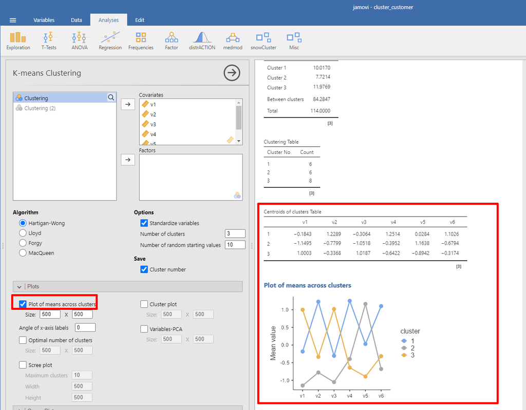

Clusters are interpreted and characterized by interpreting cluster centroids (averages). The centroids represent the average of the observation units belonging to the clusters, calculated based on all variables. The centroids allow us to assign a name or label to each cluster.

It is often helpful to include variables that were not used in the cluster analysis when interpreting and characterizing clusters. These could be demographic data, for example.